# raining prediction

## Step 1: Importing data

```python
import pandas as pd
import numpy as np
data=pd.read_csv('/Users/rachelzy/Desktop/STUDY/assignment1/weatherAUS.csv')
data
```

|  | Date | Location | MinTemp | MaxTemp | Rainfall | Evaporation | Sunshine | WindGustDir | WindGustSpeed | WindDir9am | ... | Humidity3pm | Pressure9am | Pressure3pm | Cloud9am | Cloud3pm | Temp9am | Temp3pm | RainToday | RISK_MM | RainTomorrow |
| --- | --- | --- | --- | --- | --- | --- | --- | --- | --- | --- | --- | --- | --- | --- | --- | --- | --- | --- | --- | --- | --- |
| 0 | 2008-12-01 | Albury | 13.4 | 22.9 | 0.6 | NaN | NaN | W | 44.0 | W | ... | 22.0 | 1007.7 | 1007.1 | 8.0 | NaN | 16.9 | 21.8 | No | 0.0 | No |
| 1 | 2008-12-02 | Albury | 7.4 | 25.1 | 0.0 | NaN | NaN | WNW | 44.0 | NNW | ... | 25.0 | 1010.6 | 1007.8 | NaN | NaN | 17.2 | 24.3 | No | 0.0 | No |
| 2 | 2008-12-03 | Albury | 12.9 | 25.7 | 0.0 | NaN | NaN | WSW | 46.0 | W | ... | 30.0 | 1007.6 | 1008.7 | NaN | 2.0 | 21.0 | 23.2 | No | 0.0 | No |
| 3 | 2008-12-04 | Albury | 9.2 | 28.0 | 0.0 | NaN | NaN | NE | 24.0 | SE | ... | 16.0 | 1017.6 | 1012.8 | NaN | NaN | 18.1 | 26.5 | No | 1.0 | No |
| 4 | 2008-12-05 | Albury | 17.5 | 32.3 | 1.0 | NaN | NaN | W | 41.0 | ENE | ... | 33.0 | 1010.8 | 1006.0 | 7.0 | 8.0 | 17.8 | 29.7 | No | 0.2 | No |
| ... | ... | ... | ... | ... | ... | ... | ... | ... | ... | ... | ... | ... | ... | ... | ... | ... | ... | ... | ... | ... | ... |
| 142188 | 2017-06-20 | Uluru | 3.5 | 21.8 | 0.0 | NaN | NaN | E | 31.0 | ESE | ... | 27.0 | 1024.7 | 1021.2 | NaN | NaN | 9.4 | 20.9 | No | 0.0 | No |
| 142189 | 2017-06-21 | Uluru | 2.8 | 23.4 | 0.0 | NaN | NaN | E | 31.0 | SE | ... | 24.0 | 1024.6 | 1020.3 | NaN | NaN | 10.1 | 22.4 | No | 0.0 | No |
| 142190 | 2017-06-22 | Uluru | 3.6 | 25.3 | 0.0 | NaN | NaN | NNW | 22.0 | SE | ... | 21.0 | 1023.5 | 1019.1 | NaN | NaN | 10.9 | 24.5 | No | 0.0 | No |
| 142191 | 2017-06-23 | Uluru | 5.4 | 26.9 | 0.0 | NaN | NaN | N | 37.0 | SE | ... | 24.0 | 1021.0 | 1016.8 | NaN | NaN | 12.5 | 26.1 | No | 0.0 | No |
| 142192 | 2017-06-24 | Uluru | 7.8 | 27.0 | 0.0 | NaN | NaN | SE | 28.0 | SSE | ... | 24.0 | 1019.4 | 1016.5 | 3.0 | 2.0 | 15.1 | 26.0 | No | 0.0 | No |

142193 rows × 24 columns

```python
#drop the feature, RISK_MM
data=data.drop(['RISK_MM'],axis=1)
data
```

|  | Date | Location | MinTemp | MaxTemp | Rainfall | Evaporation | Sunshine | WindGustDir | WindGustSpeed | WindDir9am | ... | Humidity9am | Humidity3pm | Pressure9am | Pressure3pm | Cloud9am | Cloud3pm | Temp9am | Temp3pm | RainToday | RainTomorrow |
| --- | --- | --- | --- | --- | --- | --- | --- | --- | --- | --- | --- | --- | --- | --- | --- | --- | --- | --- | --- | --- | --- |
| 0 | 2008-12-01 | Albury | 13.4 | 22.9 | 0.6 | NaN | NaN | W | 44.0 | W | ... | 71.0 | 22.0 | 1007.7 | 1007.1 | 8.0 | NaN | 16.9 | 21.8 | No | No |
| 1 | 2008-12-02 | Albury | 7.4 | 25.1 | 0.0 | NaN | NaN | WNW | 44.0 | NNW | ... | 44.0 | 25.0 | 1010.6 | 1007.8 | NaN | NaN | 17.2 | 24.3 | No | No |
| 2 | 2008-12-03 | Albury | 12.9 | 25.7 | 0.0 | NaN | NaN | WSW | 46.0 | W | ... | 38.0 | 30.0 | 1007.6 | 1008.7 | NaN | 2.0 | 21.0 | 23.2 | No | No |
| 3 | 2008-12-04 | Albury | 9.2 | 28.0 | 0.0 | NaN | NaN | NE | 24.0 | SE | ... | 45.0 | 16.0 | 1017.6 | 1012.8 | NaN | NaN | 18.1 | 26.5 | No | No |
| 4 | 2008-12-05 | Albury | 17.5 | 32.3 | 1.0 | NaN | NaN | W | 41.0 | ENE | ... | 82.0 | 33.0 | 1010.8 | 1006.0 | 7.0 | 8.0 | 17.8 | 29.7 | No | No |
| ... | ... | ... | ... | ... | ... | ... | ... | ... | ... | ... | ... | ... | ... | ... | ... | ... | ... | ... | ... | ... | ... |
| 142188 | 2017-06-20 | Uluru | 3.5 | 21.8 | 0.0 | NaN | NaN | E | 31.0 | ESE | ... | 59.0 | 27.0 | 1024.7 | 1021.2 | NaN | NaN | 9.4 | 20.9 | No | No |
| 142189 | 2017-06-21 | Uluru | 2.8 | 23.4 | 0.0 | NaN | NaN | E | 31.0 | SE | ... | 51.0 | 24.0 | 1024.6 | 1020.3 | NaN | NaN | 10.1 | 22.4 | No | No |
| 142190 | 2017-06-22 | Uluru | 3.6 | 25.3 | 0.0 | NaN | NaN | NNW | 22.0 | SE | ... | 56.0 | 21.0 | 1023.5 | 1019.1 | NaN | NaN | 10.9 | 24.5 | No | No |
| 142191 | 2017-06-23 | Uluru | 5.4 | 26.9 | 0.0 | NaN | NaN | N | 37.0 | SE | ... | 53.0 | 24.0 | 1021.0 | 1016.8 | NaN | NaN | 12.5 | 26.1 | No | No |
| 142192 | 2017-06-24 | Uluru | 7.8 | 27.0 | 0.0 | NaN | NaN | SE | 28.0 | SSE | ... | 51.0 | 24.0 | 1019.4 | 1016.5 | 3.0 | 2.0 | 15.1 | 26.0 | No | No |

142193 rows × 23 columns

## Step 2: Exploring the data

```python
data.head(10)
```

|  | Date | Location | MinTemp | MaxTemp | Rainfall | Evaporation | Sunshine | WindGustDir | WindGustSpeed | WindDir9am | ... | Humidity9am | Humidity3pm | Pressure9am | Pressure3pm | Cloud9am | Cloud3pm | Temp9am | Temp3pm | RainToday | RainTomorrow |
| --- | --- | --- | --- | --- | --- | --- | --- | --- | --- | --- | --- | --- | --- | --- | --- | --- | --- | --- | --- | --- | --- |
| 0 | 2008-12-01 | Albury | 13.4 | 22.9 | 0.6 | NaN | NaN | W | 44.0 | W | ... | 71.0 | 22.0 | 1007.7 | 1007.1 | 8.0 | NaN | 16.9 | 21.8 | No | No |
| 1 | 2008-12-02 | Albury | 7.4 | 25.1 | 0.0 | NaN | NaN | WNW | 44.0 | NNW | ... | 44.0 | 25.0 | 1010.6 | 1007.8 | NaN | NaN | 17.2 | 24.3 | No | No |
| 2 | 2008-12-03 | Albury | 12.9 | 25.7 | 0.0 | NaN | NaN | WSW | 46.0 | W | ... | 38.0 | 30.0 | 1007.6 | 1008.7 | NaN | 2.0 | 21.0 | 23.2 | No | No |
| 3 | 2008-12-04 | Albury | 9.2 | 28.0 | 0.0 | NaN | NaN | NE | 24.0 | SE | ... | 45.0 | 16.0 | 1017.6 | 1012.8 | NaN | NaN | 18.1 | 26.5 | No | No |
| 4 | 2008-12-05 | Albury | 17.5 | 32.3 | 1.0 | NaN | NaN | W | 41.0 | ENE | ... | 82.0 | 33.0 | 1010.8 | 1006.0 | 7.0 | 8.0 | 17.8 | 29.7 | No | No |
| 5 | 2008-12-06 | Albury | 14.6 | 29.7 | 0.2 | NaN | NaN | WNW | 56.0 | W | ... | 55.0 | 23.0 | 1009.2 | 1005.4 | NaN | NaN | 20.6 | 28.9 | No | No |
| 6 | 2008-12-07 | Albury | 14.3 | 25.0 | 0.0 | NaN | NaN | W | 50.0 | SW | ... | 49.0 | 19.0 | 1009.6 | 1008.2 | 1.0 | NaN | 18.1 | 24.6 | No | No |
| 7 | 2008-12-08 | Albury | 7.7 | 26.7 | 0.0 | NaN | NaN | W | 35.0 | SSE | ... | 48.0 | 19.0 | 1013.4 | 1010.1 | NaN | NaN | 16.3 | 25.5 | No | No |
| 8 | 2008-12-09 | Albury | 9.7 | 31.9 | 0.0 | NaN | NaN | NNW | 80.0 | SE | ... | 42.0 | 9.0 | 1008.9 | 1003.6 | NaN | NaN | 18.3 | 30.2 | No | Yes |
| 9 | 2008-12-10 | Albury | 13.1 | 30.1 | 1.4 | NaN | NaN | W | 28.0 | S | ... | 58.0 | 27.0 | 1007.0 | 1005.7 | NaN | NaN | 20.1 | 28.2 | Yes | No |

10 rows × 23 columns

```python
data.info()
```

```
<class 'pandas.core.frame.DataFrame'>
RangeIndex: 142193 entries, 0 to 142192
Data columns (total 23 columns):
 #   Column         Non-Null Count   Dtype
---  ------         --------------   -----
 0   Date           142193 non-null  object
 1   Location       142193 non-null  object
 2   MinTemp        141556 non-null  float64
 3   MaxTemp        141871 non-null  float64
 4   Rainfall       140787 non-null  float64
 5   Evaporation    81350 non-null   float64
 6   Sunshine       74377 non-null   float64
 7   WindGustDir    132863 non-null  object
 8   WindGustSpeed  132923 non-null  float64
 9   WindDir9am     132180 non-null  object
 10  WindDir3pm     138415 non-null  object
 11  WindSpeed9am   140845 non-null  float64
 12  WindSpeed3pm   139563 non-null  float64
 13  Humidity9am    140419 non-null  float64
 14  Humidity3pm    138583 non-null  float64
 15  Pressure9am    128179 non-null  float64
 16  Pressure3pm    128212 non-null  float64
 17  Cloud9am       88536 non-null   float64
 18  Cloud3pm       85099 non-null   float64
 19  Temp9am        141289 non-null  float64
 20  Temp3pm        139467 non-null  float64
 21  RainToday      140787 non-null  object
 22  RainTomorrow   142193 non-null  object
dtypes: float64(16), object(7)
memory usage: 25.0+ MB
```

```python
data.describe()
```

|  | MinTemp | MaxTemp | Rainfall | Evaporation | Sunshine | WindGustSpeed | WindSpeed9am | WindSpeed3pm | Humidity9am | Humidity3pm | Pressure9am | Pressure3pm | Cloud9am | Cloud3pm | Temp9am | Temp3pm |
| --- | --- | --- | --- | --- | --- | --- | --- | --- | --- | --- | --- | --- | --- | --- | --- | --- |
| count | 141556.000000 | 141871.000000 | 140787.000000 | 81350.000000 | 74377.000000 | 132923.000000 | 140845.000000 | 139563.000000 | 140419.000000 | 138583.000000 | 128179.000000 | 128212.000000 | 88536.000000 | 85099.000000 | 141289.000000 | 139467.000000 |
| mean | 12.186400 | 23.226784 | 2.349974 | 5.469824 | 7.624853 | 39.984292 | 14.001988 | 18.637576 | 68.843810 | 51.482606 | 1017.653758 | 1015.258204 | 4.437189 | 4.503167 | 16.987509 | 21.687235 |
| std | 6.403283 | 7.117618 | 8.465173 | 4.188537 | 3.781525 | 13.588801 | 8.893337 | 8.803345 | 19.051293 | 20.797772 | 7.105476 | 7.036677 | 2.887016 | 2.720633 | 6.492838 | 6.937594 |
| min | -8.500000 | -4.800000 | 0.000000 | 0.000000 | 0.000000 | 6.000000 | 0.000000 | 0.000000 | 0.000000 | 0.000000 | 980.500000 | 977.100000 | 0.000000 | 0.000000 | -7.200000 | -5.400000 |
| 25% | 7.600000 | 17.900000 | 0.000000 | 2.600000 | 4.900000 | 31.000000 | 7.000000 | 13.000000 | 57.000000 | 37.000000 | 1012.900000 | 1010.400000 | 1.000000 | 2.000000 | 12.300000 | 16.600000 |
| 50% | 12.000000 | 22.600000 | 0.000000 | 4.800000 | 8.500000 | 39.000000 | 13.000000 | 19.000000 | 70.000000 | 52.000000 | 1017.600000 | 1015.200000 | 5.000000 | 5.000000 | 16.700000 | 21.100000 |
| 75% | 16.800000 | 28.200000 | 0.800000 | 7.400000 | 10.600000 | 48.000000 | 19.000000 | 24.000000 | 83.000000 | 66.000000 | 1022.400000 | 1020.000000 | 7.000000 | 7.000000 | 21.600000 | 26.400000 |
| max | 33.900000 | 48.100000 | 371.000000 | 145.000000 | 14.500000 | 135.000000 | 130.000000 | 87.000000 | 100.000000 | 100.000000 | 1041.000000 | 1039.600000 | 9.000000 | 9.000000 | 40.200000 | 46.700000 |

```python
data.describe(include='object')
```

|  | Date | Location | WindGustDir | WindDir9am | WindDir3pm | RainToday | RainTomorrow |
| --- | --- | --- | --- | --- | --- | --- | --- |
| count | 142193 | 142193 | 132863 | 132180 | 138415 | 140787 | 142193 |
| unique | 3436 | 49 | 16 | 16 | 16 | 2 | 2 |
| top | 2013-12-01 | Canberra | W | N | SE | No | No |
| freq | 49 | 3418 | 9780 | 11393 | 10663 | 109332 | 110316 |

```python
#explore the RainTomorrow feature
data['RainTomorrow'].unique()
```

```
array(['No', 'Yes'], dtype=object)
```

```
RainTomorrow
No     110316
Yes     31877
Name: Date, dtype: int64
```

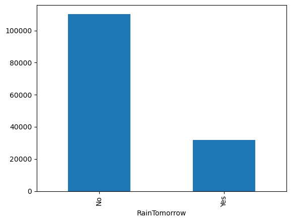

```python
#explore the RainTomorrow feature
RTData=data.groupby('RainTomorrow')['Date'].count()
print(RTData)
RTData.plot(x=RTData.index, y=RTData, kind="bar")
```

```python
### Visualization
```

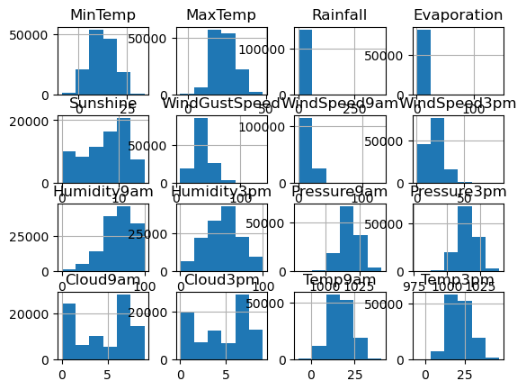

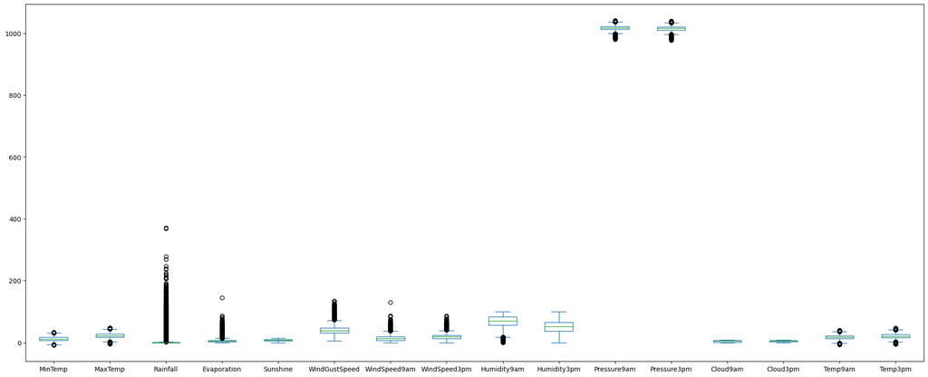

```python
data.hist(bins=6)
data.plot(kind="box", figsize=(25, 10))
```

```python
#get the features (column labels) that are categorical
cate_data = data.select_dtypes(include=['object']).columns
cate_data
```

```
Index(['Date', 'Location', 'WindGustDir', 'WindDir9am', 'WindDir3pm',
       'RainToday', 'RainTomorrow'],
      dtype='object')
```

```python
#get the features (column labels) that are numerical
num_data = data.select_dtypes(include=[np.number]).columns
num_data
```

```
Index(['MinTemp', 'MaxTemp', 'Rainfall', 'Evaporation', 'Sunshine',
       'WindGustSpeed', 'WindSpeed9am', 'WindSpeed3pm', 'Humidity9am',
       'Humidity3pm', 'Pressure9am', 'Pressure3pm', 'Cloud9am', 'Cloud3pm',
       'Temp9am', 'Temp3pm'],
      dtype='object')
```

## Step 3: Transforming data

```python
data['Date']=pd.to_datetime(data['Date'],format='%Y-%m-%d')
data['Date']
```

```
0        2008-12-01
1        2008-12-02
2        2008-12-03
3        2008-12-04
4        2008-12-05
            ...
142188   2017-06-20
142189   2017-06-21
142190   2017-06-22
142191   2017-06-23
142192   2017-06-24
Name: Date, Length: 142193, dtype: datetime64[ns]
```

```python
#show data types of the converted data
data.dtypes
```

```
Date             datetime64[ns]
Location                 object
MinTemp                 float64
MaxTemp                 float64
Rainfall                float64
Evaporation             float64
Sunshine                float64
WindGustDir              object
WindGustSpeed           float64
WindDir9am               object
WindDir3pm               object
WindSpeed9am            float64
WindSpeed3pm            float64
Humidity9am             float64
Humidity3pm             float64
Pressure9am             float64
Pressure3pm             float64
Cloud9am                float64
Cloud3pm                float64
Temp9am                 float64
Temp3pm                 float64
RainToday                object
RainTomorrow             object
dtype: object
```

```python
#Extract the year, month, day attributes of the datetime objects converted for the Date feature
#create the corresponding new features Year, Month and Day

data['Year']=data['Date'].dt.year
data['Month'] = data['Date'].dt.month
data['Day'] = data['Date'].dt.day
data
```

|  | Date | Location | MinTemp | MaxTemp | Rainfall | Evaporation | Sunshine | WindGustDir | WindGustSpeed | WindDir9am | ... | Pressure3pm | Cloud9am | Cloud3pm | Temp9am | Temp3pm | RainToday | RainTomorrow | Year | Month | Day |
| --- | --- | --- | --- | --- | --- | --- | --- | --- | --- | --- | --- | --- | --- | --- | --- | --- | --- | --- | --- | --- | --- |
| 0 | 2008-12-01 | Albury | 13.4 | 22.9 | 0.6 | NaN | NaN | W | 44.0 | W | ... | 1007.1 | 8.0 | NaN | 16.9 | 21.8 | No | No | 2008 | 12 | 1 |
| 1 | 2008-12-02 | Albury | 7.4 | 25.1 | 0.0 | NaN | NaN | WNW | 44.0 | NNW | ... | 1007.8 | NaN | NaN | 17.2 | 24.3 | No | No | 2008 | 12 | 2 |
| 2 | 2008-12-03 | Albury | 12.9 | 25.7 | 0.0 | NaN | NaN | WSW | 46.0 | W | ... | 1008.7 | NaN | 2.0 | 21.0 | 23.2 | No | No | 2008 | 12 | 3 |
| 3 | 2008-12-04 | Albury | 9.2 | 28.0 | 0.0 | NaN | NaN | NE | 24.0 | SE | ... | 1012.8 | NaN | NaN | 18.1 | 26.5 | No | No | 2008 | 12 | 4 |
| 4 | 2008-12-05 | Albury | 17.5 | 32.3 | 1.0 | NaN | NaN | W | 41.0 | ENE | ... | 1006.0 | 7.0 | 8.0 | 17.8 | 29.7 | No | No | 2008 | 12 | 5 |
| ... | ... | ... | ... | ... | ... | ... | ... | ... | ... | ... | ... | ... | ... | ... | ... | ... | ... | ... | ... | ... | ... |
| 142188 | 2017-06-20 | Uluru | 3.5 | 21.8 | 0.0 | NaN | NaN | E | 31.0 | ESE | ... | 1021.2 | NaN | NaN | 9.4 | 20.9 | No | No | 2017 | 6 | 20 |
| 142189 | 2017-06-21 | Uluru | 2.8 | 23.4 | 0.0 | NaN | NaN | E | 31.0 | SE | ... | 1020.3 | NaN | NaN | 10.1 | 22.4 | No | No | 2017 | 6 | 21 |
| 142190 | 2017-06-22 | Uluru | 3.6 | 25.3 | 0.0 | NaN | NaN | NNW | 22.0 | SE | ... | 1019.1 | NaN | NaN | 10.9 | 24.5 | No | No | 2017 | 6 | 22 |
| 142191 | 2017-06-23 | Uluru | 5.4 | 26.9 | 0.0 | NaN | NaN | N | 37.0 | SE | ... | 1016.8 | NaN | NaN | 12.5 | 26.1 | No | No | 2017 | 6 | 23 |
| 142192 | 2017-06-24 | Uluru | 7.8 | 27.0 | 0.0 | NaN | NaN | SE | 28.0 | SSE | ... | 1016.5 | 3.0 | 2.0 | 15.1 | 26.0 | No | No | 2017 | 6 | 24 |

142193 rows × 26 columns

```python
data = data.drop(['Date'],axis=1)
data
```

|  | Location | MinTemp | MaxTemp | Rainfall | Evaporation | Sunshine | WindGustDir | WindGustSpeed | WindDir9am | WindDir3pm | ... | Pressure3pm | Cloud9am | Cloud3pm | Temp9am | Temp3pm | RainToday | RainTomorrow | Year | Month | Day |
| --- | --- | --- | --- | --- | --- | --- | --- | --- | --- | --- | --- | --- | --- | --- | --- | --- | --- | --- | --- | --- | --- |
| 0 | Albury | 13.4 | 22.9 | 0.6 | NaN | NaN | W | 44.0 | W | WNW | ... | 1007.1 | 8.0 | NaN | 16.9 | 21.8 | No | No | 2008 | 12 | 1 |
| 1 | Albury | 7.4 | 25.1 | 0.0 | NaN | NaN | WNW | 44.0 | NNW | WSW | ... | 1007.8 | NaN | NaN | 17.2 | 24.3 | No | No | 2008 | 12 | 2 |
| 2 | Albury | 12.9 | 25.7 | 0.0 | NaN | NaN | WSW | 46.0 | W | WSW | ... | 1008.7 | NaN | 2.0 | 21.0 | 23.2 | No | No | 2008 | 12 | 3 |
| 3 | Albury | 9.2 | 28.0 | 0.0 | NaN | NaN | NE | 24.0 | SE | E | ... | 1012.8 | NaN | NaN | 18.1 | 26.5 | No | No | 2008 | 12 | 4 |
| 4 | Albury | 17.5 | 32.3 | 1.0 | NaN | NaN | W | 41.0 | ENE | NW | ... | 1006.0 | 7.0 | 8.0 | 17.8 | 29.7 | No | No | 2008 | 12 | 5 |
| ... | ... | ... | ... | ... | ... | ... | ... | ... | ... | ... | ... | ... | ... | ... | ... | ... | ... | ... | ... | ... | ... |
| 142188 | Uluru | 3.5 | 21.8 | 0.0 | NaN | NaN | E | 31.0 | ESE | E | ... | 1021.2 | NaN | NaN | 9.4 | 20.9 | No | No | 2017 | 6 | 20 |
| 142189 | Uluru | 2.8 | 23.4 | 0.0 | NaN | NaN | E | 31.0 | SE | ENE | ... | 1020.3 | NaN | NaN | 10.1 | 22.4 | No | No | 2017 | 6 | 21 |
| 142190 | Uluru | 3.6 | 25.3 | 0.0 | NaN | NaN | NNW | 22.0 | SE | N | ... | 1019.1 | NaN | NaN | 10.9 | 24.5 | No | No | 2017 | 6 | 22 |
| 142191 | Uluru | 5.4 | 26.9 | 0.0 | NaN | NaN | N | 37.0 | SE | WNW | ... | 1016.8 | NaN | NaN | 12.5 | 26.1 | No | No | 2017 | 6 | 23 |
| 142192 | Uluru | 7.8 | 27.0 | 0.0 | NaN | NaN | SE | 28.0 | SSE | N | ... | 1016.5 | 3.0 | 2.0 | 15.1 | 26.0 | No | No | 2017 | 6 | 24 |

142193 rows × 25 columns

## Step 4: Preparing Training and Testing Datasets

Prepare data - feature set and target set

Build target set Y by extracting 'RainTomorrow' from data Build feature set X by excluding/dropping the 'RainTomorrow' from data

```python
Y=data['RainTomorrow']
X=data.drop(['RainTomorrow'], axis=1)
print(X)
print(Y)
```

```
       Location  MinTemp  MaxTemp  Rainfall  Evaporation  Sunshine  \
0        Albury     13.4     22.9       0.6          NaN       NaN
1        Albury      7.4     25.1       0.0          NaN       NaN
2        Albury     12.9     25.7       0.0          NaN       NaN
3        Albury      9.2     28.0       0.0          NaN       NaN
4        Albury     17.5     32.3       1.0          NaN       NaN
...         ...      ...      ...       ...          ...       ...
142188    Uluru      3.5     21.8       0.0          NaN       NaN
142189    Uluru      2.8     23.4       0.0          NaN       NaN
142190    Uluru      3.6     25.3       0.0          NaN       NaN
142191    Uluru      5.4     26.9       0.0          NaN       NaN
142192    Uluru      7.8     27.0       0.0          NaN       NaN

       WindGustDir  WindGustSpeed WindDir9am WindDir3pm  ...  Pressure9am  \
0                W           44.0          W        WNW  ...       1007.7
```

[output cut: 50 more lines]

### Step 4.2

Split the data into training and testing datasets

Using the sklearn.model_selection.train_test_split() function to split the training data, feature set and target set (i.e. X and Y), into two subsets for training and testing, i.e. X_train, X_test, Y_train, Y_test.

Set test_size to 0.3. test_size is the proportion of the dataset to include in the test split. Set random_state to 0. This integer value is the seed used by the random number generator. Set stratify to stratify the dataset based on the target labels (i.e. Y).

```python
from sklearn.model_selection import train_test_split

X_train, X_test, Y_train, Y_test = train_test_split(X, Y, test_size=0.3, random_state=0, stratify=Y)
```

```python
#show info of the splited sets
print("X_train : " + str(X_train.shape))
print("X_test : " + str(X_test.shape))
print("y_train : " + str(Y_train.shape))
print("y_test : " + str(Y_test.shape))
```

```
X_train : (99535, 24)
X_test : (42658, 24)
y_train : (99535,)
y_test : (42658,)
```

## Step 5: Cleaning data: Handling missing values

### Step 5.1 Missing values in the training dataset

count how many values were missing in the dataset

```python
X_train.isnull().sum()
```

```
Location             0
MinTemp            435
MaxTemp            217
Rainfall           967
Evaporation      42619
Sunshine         47534
WindGustDir       6535
WindGustSpeed     6490
WindDir9am        7035
WindDir3pm        2666
WindSpeed9am       954
WindSpeed3pm      1861
Humidity9am       1241
Humidity3pm       2534
Pressure9am       9833
Pressure3pm       9808
Cloud9am         37689
Cloud3pm         40024
Temp9am            617
Temp3pm           1907
RainToday          967
Year                 0
Month                0
Day                  0
dtype: int64
```

### Step 5.2 Categorical features with missing values of the training dataset

use the most common value of the feature to impute the missing values.

```python
X_train["WindGustDir"].fillna(X_train['WindGustDir'].mode().iloc[0], inplace=True)
X_train["WindDir9am"].fillna(X_train['WindDir9am'].mode().iloc[0], inplace=True)
X_train["WindDir3pm"].fillna(X_train['WindDir3pm'].mode().iloc[0], inplace=True)
X_train["RainToday"].fillna(X_train["RainToday"].mode().iloc[0], inplace=True)
```

### Step 5.3 Numerical features with missing values of the training dataset

Use mean / median to impute the missing values of the feature

```python
numeric_list = ["MinTemp", "MaxTemp", "Rainfall", "Evaporation", "Sunshine", "WindGustSpeed", "WindSpeed9am", "WindSpeed3pm", "Humidity9am", "Humidity3pm",
"Pressure9am", "Pressure3pm", "Cloud9am", "Cloud3pm", "Temp9am", "Temp3pm"]

for i in numeric_list:
    X_train[i].fillna(X_train[i].mean(), inplace=True)
```

### Step 5.4 Handling missing values of the testing dataset

```python
X_test["WindGustDir"].fillna(X_test['WindGustDir'].mode().iloc[0], inplace=True)
X_test["WindDir9am"].fillna(X_test['WindDir9am'].mode().iloc[0], inplace=True)
X_test["WindDir3pm"].fillna(X_test['WindDir3pm'].mode().iloc[0], inplace=True)
X_test["RainToday"].fillna(X_test["RainToday"].mode().iloc[0], inplace=True)
```

```python
numeric_list = ["MinTemp", "MaxTemp", "Rainfall", "Evaporation", "Sunshine", "WindGustSpeed", "WindSpeed9am", "WindSpeed3pm", "Humidity9am", "Humidity3pm",
"Pressure9am", "Pressure3pm", "Cloud9am", "Cloud3pm", "Temp9am", "Temp3pm"]

for i in numeric_list:
    X_test[i].fillna(X_test[i].mean(), inplace=True)
```

## Step 6 convert categorical features into dummy/indicator features of the dataset

```python
X_train = pd.get_dummies(X_train)
X_train.head(10)
```

|  | MinTemp | MaxTemp | Rainfall | Evaporation | Sunshine | WindGustSpeed | WindSpeed9am | WindSpeed3pm | Humidity9am | Humidity3pm | ... | WindDir3pm_S | WindDir3pm_SE | WindDir3pm_SSE | WindDir3pm_SSW | WindDir3pm_SW | WindDir3pm_W | WindDir3pm_WNW | WindDir3pm_WSW | RainToday_No | RainToday_Yes |
| --- | --- | --- | --- | --- | --- | --- | --- | --- | --- | --- | --- | --- | --- | --- | --- | --- | --- | --- | --- | --- | --- |
| 26962 | 17.6 | 30.0 | 0.0 | 9.000000 | 7.616786 | 44.0 | 0.000000 | 9.0 | 88.0 | 57.0 | ... | False | False | False | False | False | False | False | False | True | False |
| 100114 | 5.7 | 17.0 | 0.0 | 2.400000 | 4.700000 | 20.0 | 14.003368 | 9.0 | 86.0 | 50.0 | ... | False | False | True | False | False | False | False | False | True | False |
| 2881 | 23.9 | 40.7 | 0.0 | 5.471291 | 7.616786 | 39.0 | 6.000000 | 7.0 | 61.0 | 32.0 | ... | False | False | False | False | False | False | False | False | True | False |
| 100638 | 5.1 | 20.8 | 0.0 | 6.200000 | 7.616786 | 48.0 | 19.000000 | 28.0 | 67.0 | 40.0 | ... | False | False | False | False | False | True | False | False | True | False |
| 35032 | 15.2 | 24.3 | 2.6 | 3.200000 | 9.800000 | 69.0 | 15.000000 | 31.0 | 66.0 | 30.0 | ... | False | False | False | False | False | False | True | False | False | True |
| 97847 | 8.4 | 14.4 | 7.2 | 0.200000 | 0.100000 | 81.0 | 33.000000 | 37.0 | 87.0 | 87.0 | ... | False | False | False | False | False | False | False | False | False | True |
| 123095 | 0.0 | 18.5 | 0.2 | 5.471291 | 7.616786 | 31.0 | 15.000000 | 13.0 | 74.0 | 38.0 | ... | False | False | False | False | False | False | False | False | True | False |
| 128291 | 14.8 | 27.7 | 0.0 | 5.800000 | 8.500000 | 35.0 | 24.000000 | 19.0 | 79.0 | 32.0 | ... | False | True | False | False | False | False | False | False | True | False |
| 135951 | 17.4 | 30.3 | 0.0 | 5.400000 | 8.700000 | 33.0 | 17.000000 | 22.0 | 66.0 | 54.0 | ... | False | False | False | False | False | False | False | False | True | False |
| 54673 | 3.3 | 15.9 | 0.0 | 5.471291 | 7.616786 | 39.0 | 17.000000 | 13.0 | 81.0 | 50.0 | ... | False | False | False | False | False | False | False | False | True | False |

10 rows × 118 columns

```python
X_test = pd.get_dummies(X_test)
X_test.head(10)
```

|  | MinTemp | MaxTemp | Rainfall | Evaporation | Sunshine | WindGustSpeed | WindSpeed9am | WindSpeed3pm | Humidity9am | Humidity3pm | ... | WindDir3pm_S | WindDir3pm_SE | WindDir3pm_SSE | WindDir3pm_SSW | WindDir3pm_SW | WindDir3pm_W | WindDir3pm_WNW | WindDir3pm_WSW | RainToday_No | RainToday_Yes |
| --- | --- | --- | --- | --- | --- | --- | --- | --- | --- | --- | --- | --- | --- | --- | --- | --- | --- | --- | --- | --- | --- |
| 115133 | 28.6 | 41.1 | 0.000000 | 11.400000 | 7.7000 | 43.000000 | 26.0 | 17.0 | 19.0 | 12.0 | ... | False | False | False | False | False | False | False | False | True | False |
| 100239 | 5.3 | 15.8 | 0.800000 | 10.200000 | 2.3000 | 74.000000 | 22.0 | 20.0 | 57.0 | 78.0 | ... | False | False | False | False | False | False | False | False | True | False |
| 90301 | 19.5 | 28.8 | 0.000000 | 5.466407 | 7.6436 | 28.000000 | 17.0 | 19.0 | 59.0 | 56.0 | ... | False | False | False | False | False | False | False | False | True | False |
| 57936 | 3.4 | 18.9 | 0.000000 | 5.466407 | 7.6436 | 30.000000 | 7.0 | 22.0 | 81.0 | 36.0 | ... | False | False | False | False | False | False | False | False | True | False |
| 26854 | 16.2 | 23.9 | 0.600000 | 1.900000 | 7.6436 | 39.000000 | 9.0 | 24.0 | 77.0 | 65.0 | ... | False | False | False | False | False | False | False | False | True | False |
| 41316 | 8.4 | 22.4 | 0.000000 | 5.466407 | 7.6436 | 28.000000 | 7.0 | 17.0 | 82.0 | 58.0 | ... | False | False | False | False | False | False | False | False | True | False |
| 29605 | 10.7 | 20.5 | 0.000000 | 4.400000 | 9.9000 | 39.982296 | 22.0 | 7.0 | 58.0 | 36.0 | ... | False | False | False | False | False | False | True | False | True | False |
| 111054 | 11.7 | 28.4 | 2.324108 | 5.466407 | 7.6436 | 35.000000 | 17.0 | 20.0 | 47.0 | 39.0 | ... | False | False | False | False | False | False | False | True | True | False |
| 82903 | 16.4 | 27.9 | 0.000000 | 9.800000 | 8.7000 | 22.000000 | 4.0 | 9.0 | 58.0 | 54.0 | ... | False | False | False | False | False | False | False | False | True | False |
| 113538 | 16.9 | 32.9 | 0.000000 | 5.466407 | 12.6000 | 43.000000 | 17.0 | 30.0 | 35.0 | 38.0 | ... | False | False | False | False | True | False | False | False | True | False |

10 rows × 118 columns

### Step 6.1 Align the testing dataset with the training dataset

```python
X_train, X_test = X_train.align(X_test, join="left", axis=1)
X_test.head(10)
```

|  | MinTemp | MaxTemp | Rainfall | Evaporation | Sunshine | WindGustSpeed | WindSpeed9am | WindSpeed3pm | Humidity9am | Humidity3pm | ... | WindDir3pm_S | WindDir3pm_SE | WindDir3pm_SSE | WindDir3pm_SSW | WindDir3pm_SW | WindDir3pm_W | WindDir3pm_WNW | WindDir3pm_WSW | RainToday_No | RainToday_Yes |
| --- | --- | --- | --- | --- | --- | --- | --- | --- | --- | --- | --- | --- | --- | --- | --- | --- | --- | --- | --- | --- | --- |
| 115133 | 28.6 | 41.1 | 0.000000 | 11.400000 | 7.7000 | 43.000000 | 26.0 | 17.0 | 19.0 | 12.0 | ... | False | False | False | False | False | False | False | False | True | False |
| 100239 | 5.3 | 15.8 | 0.800000 | 10.200000 | 2.3000 | 74.000000 | 22.0 | 20.0 | 57.0 | 78.0 | ... | False | False | False | False | False | False | False | False | True | False |
| 90301 | 19.5 | 28.8 | 0.000000 | 5.466407 | 7.6436 | 28.000000 | 17.0 | 19.0 | 59.0 | 56.0 | ... | False | False | False | False | False | False | False | False | True | False |
| 57936 | 3.4 | 18.9 | 0.000000 | 5.466407 | 7.6436 | 30.000000 | 7.0 | 22.0 | 81.0 | 36.0 | ... | False | False | False | False | False | False | False | False | True | False |
| 26854 | 16.2 | 23.9 | 0.600000 | 1.900000 | 7.6436 | 39.000000 | 9.0 | 24.0 | 77.0 | 65.0 | ... | False | False | False | False | False | False | False | False | True | False |
| 41316 | 8.4 | 22.4 | 0.000000 | 5.466407 | 7.6436 | 28.000000 | 7.0 | 17.0 | 82.0 | 58.0 | ... | False | False | False | False | False | False | False | False | True | False |
| 29605 | 10.7 | 20.5 | 0.000000 | 4.400000 | 9.9000 | 39.982296 | 22.0 | 7.0 | 58.0 | 36.0 | ... | False | False | False | False | False | False | True | False | True | False |
| 111054 | 11.7 | 28.4 | 2.324108 | 5.466407 | 7.6436 | 35.000000 | 17.0 | 20.0 | 47.0 | 39.0 | ... | False | False | False | False | False | False | False | True | True | False |
| 82903 | 16.4 | 27.9 | 0.000000 | 9.800000 | 8.7000 | 22.000000 | 4.0 | 9.0 | 58.0 | 54.0 | ... | False | False | False | False | False | False | False | False | True | False |
| 113538 | 16.9 | 32.9 | 0.000000 | 5.466407 | 12.6000 | 43.000000 | 17.0 | 30.0 | 35.0 | 38.0 | ... | False | False | False | False | True | False | False | False | True | False |

10 rows × 118 columns

```python
print("X_train : " + str(X_train.shape))
print("X_test : " + str(X_test.shape))
print("y_train : " + str(Y_train.shape))
print("y_test : " + str(Y_test.shape))
```

```
X_train : (99535, 118)
X_test : (42658, 118)
y_train : (99535,)
y_test : (42658,)
```

## Step 7: Training the Regression model using Sklearn

Build the logistic regression model by:

Initialize a Logistic Regression model by LogisticRegression() function. Call fit() function to train the logistic regression model using the training feature data (i.e. X_train). Predict the target values for the testing feature data (i.e. X_test) using the predict() function.

```python
from sklearn.linear_model import LogisticRegression
model = LogisticRegression(max_iter=1000)
model.fit(X_train, Y_train)
y_pred = model.predict(X_test)
y_pred
```

```
array(['No', 'Yes', 'No', ..., 'Yes', 'No', 'No'], dtype=object)
```

## step 7.1 Evaluation

```python
from sklearn.metrics import accuracy_score

accuracy_score(Y_test, y_pred)
```

```
0.8457030334286652
```

## Step 8 - Standardization and Rescaling (10 points)

Rescaling and Standardization of datasets is a common requirement for many machine learning estimators implemented in scikit-learn. They might behave badly if the individual features do not more or less look like standard normally distributed data: Gaussian with zero mean and unit variance.

```python
from sklearn.preprocessing import StandardScaler

scaler = StandardScaler()
scaler.fit(X_train)
trans_X_train = scaler.transform(X_train)
X_train = pd.DataFrame(trans_X_train, columns=X_train.columns)
X_train.head()

scaler.fit(X_test)
trans_X_test = scaler.transform(X_test)
X_test = pd.DataFrame(trans_X_test, columns=X_test.columns)
X_test.head()
```

|  | MinTemp | MaxTemp | Rainfall | Evaporation | Sunshine | WindGustSpeed | WindSpeed9am | WindSpeed3pm | Humidity9am | Humidity3pm | ... | WindDir3pm_S | WindDir3pm_SE | WindDir3pm_SSE | WindDir3pm_SSW | WindDir3pm_SW | WindDir3pm_W | WindDir3pm_WNW | WindDir3pm_WSW | RainToday_No | RainToday_Yes |
| --- | --- | --- | --- | --- | --- | --- | --- | --- | --- | --- | --- | --- | --- | --- | --- | --- | --- | --- | --- | --- | --- |
| 0 | 2.568363 | 2.518431 | -0.286507 | 1.914506 | 2.067405e-02 | 0.229944 | 1.360832 | -0.190765 | -2.632970 | -1.923379 | ... | -0.270226 | -0.335941 | -0.260765 | -0.240803 | -0.265249 | -0.27735 | -0.257417 | -0.266865 | 0.533741 | -0.533741 |
| 1 | -1.081243 | -1.049298 | -0.187886 | 1.527319 | -1.958767e+00 | 2.592088 | 0.907268 | 0.154074 | -0.622853 | 1.290734 | ... | -0.270226 | -0.335941 | -0.260765 | -0.240803 | -0.265249 | -0.27735 | -0.257417 | -0.266865 | 0.533741 | -0.533741 |
| 2 | 1.142980 | 0.783922 | -0.286507 | 0.000000 | -3.255734e-16 | -0.913030 | 0.340313 | 0.039128 | -0.517057 | 0.219363 | ... | -0.270226 | -0.335941 | -0.260765 | -0.240803 | -0.265249 | -0.27735 | -0.257417 | -0.266865 | 0.533741 | -0.533741 |
| 3 | -1.378851 | -0.612145 | -0.286507 | 0.000000 | -3.255734e-16 | -0.760633 | -0.793598 | 0.383968 | 0.646694 | -0.754611 | ... | -0.270226 | -0.335941 | -0.260765 | -0.240803 | -0.265249 | -0.27735 | -0.257417 | -0.266865 | 0.533741 | -0.533741 |
| 4 | 0.626083 | 0.092939 | -0.212541 | -1.150721 | -3.255734e-16 | -0.074849 | -0.566816 | 0.613861 | 0.435103 | 0.657651 | ... | -0.270226 | -0.335941 | -0.260765 | -0.240803 | -0.265249 | -0.27735 | -0.257417 | -0.266865 | 0.533741 | -0.533741 |

5 rows × 118 columns

## Step 9 -- Training the Regression model on the rescaled and standardized dataset

Re-train the regression model using the rescaled and standardized datasets

```python
from sklearn.metrics import accuracy_score

model = LogisticRegression(max_iter=1000)
model.fit(X_train, Y_train)
y_pred = model.predict(X_test)

accuracy_score(Y_test, y_pred)
```

```
0.8485395470955037
```